# Διάλεξη 7η, 1 Δεκεμβρίου 2016

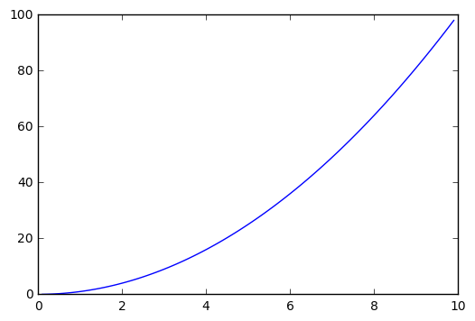

```python
def f(x):
    return x**2 # X square

X = [x/10.0 for x in range(1,100)]
Y = [f(x) for x in X]

fig, ax = plt.subplots()
ax.plot(X,Y)
plt.show()
```

Ένας καλύτερος τρόπος για να πλοτάρουμε συναρτήσεις είναι να χρησιμοποιήσουμε τη [linspace](https://docs.scipy.org/doc/numpy/reference/generated/numpy.linspace.html) της numpy. H linspace(a,b,c) δημιουργεί μία αριθμητική πρόοδο από a μέχρι b, έτσι ώστε να υπάρχουν συνολικά c στοιχεία.

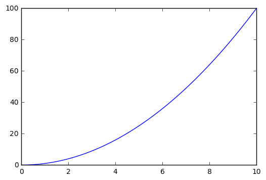

```python
import numpy as np

X = np.linspace(0, 10, 100) # 0 = min X, 10 = max X, 100 = resolution...
Y = [f(x) for x in X]

fig, ax = plt.subplots()
ax.plot(X,Y)

plt.show()
```

Το 100 στη linspace μπορούμε να το δούμε και ως την "ανάλυση της γραφικής παράστασης"

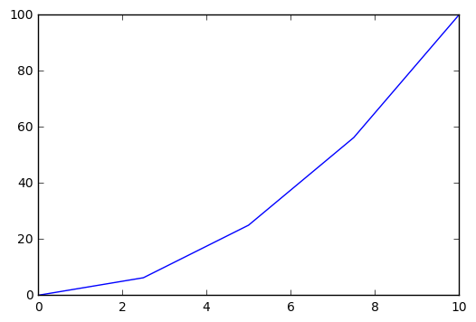

```python
X = np.linspace(0, 10, 5) # 5 = resolution
Y = [f(x) for x in X]

fig, ax = plt.subplots()
ax.plot(X,Y)

plt.show()
```

Παρατηρήστε πόσο "σπαστή" είναι η γραφική παράσταση

Με τη συνάρτηση ax.set_xlim, ax.set_ylim αλλάζουμε τα όρια των αξόνων

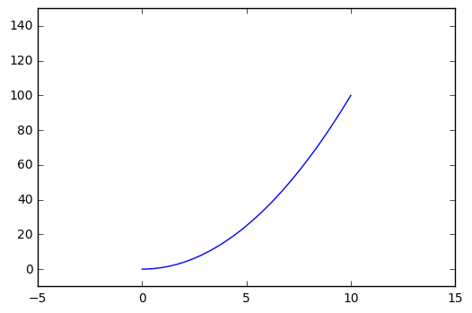

```python
fig, ax = plt.subplots()

X = np.linspace(0, 10, 100) # 0 = min X, 10 = max X, 100 = resolution...
Y = [f(x) for x in X]

ax.set_xlim(-5, 15)
ax.set_ylim(-10, 150)
ax.plot(X,Y)

plt.show()
```

Μπορούμε επίσης να βάλουμε labels στους άξονες και σε όλο το πλοτ:

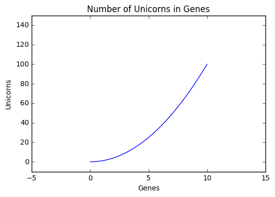

```python
fig, ax = plt.subplots()

X = np.linspace(0, 10, 100) # 0 = min X, 10 = max X, 100 = resolution...
Y = [f(x) for x in X]

ax.set_xlim(-5, 15)
ax.set_ylim(-10, 150)
ax.plot(X,Y)

ax.set_xlabel("Genes")
ax.set_ylabel("Unicorns")
ax.set_title("Number of Unicorns in Genes")


plt.show()
```

Μπορείτε να ορίσετε μέγεθος, γραμματοσειρά και στυλ στα labels

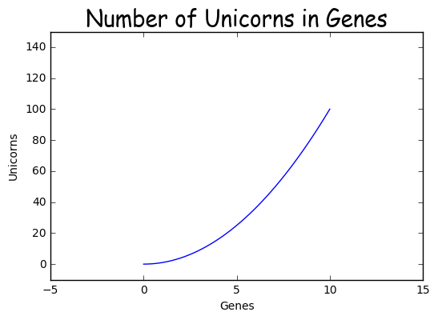

```python
fig, ax = plt.subplots()

X = np.linspace(0, 10, 100) # 0 = min X, 10 = max X, 100 = resolution...
Y = [f(x) for x in X]

ax.set_xlim(-5, 15)
ax.set_ylim(-10, 150)
ax.plot(X,Y)

ax.set_xlabel("Genes")
ax.set_ylabel("Unicorns")
ax.set_title("Number of Unicorns in Genes", fontname="Comic Sans MS", fontsize=20)


plt.show()
```

Με τη ax.set_xticks μπορείτε να ορίσεττε εσείς ποια ticks θα φαίνονται σε κάθε άξονα

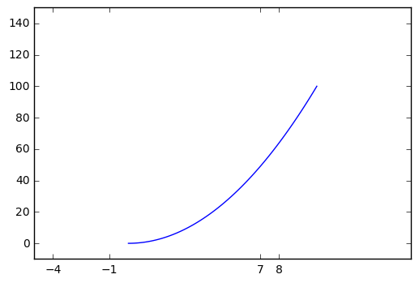

```python
fig, ax = plt.subplots()
ax.set_xlim(-5, 15)
ax.set_ylim(-10, 150)
ax.plot(X,Y)
ax.set_xticks([-4,-1,7,8])
plt.show()
```

Μπορείτε να αλλάξετε και το label του tick:

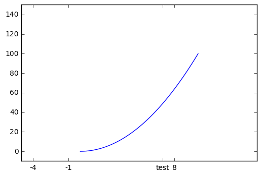

```python
fig, ax = plt.subplots()
ax.set_xlim(-5, 15)
ax.set_ylim(-10, 150)
ax.plot(X,Y)
ax.set_xticks([-4,-1,7,8])

ticks = ax.get_xticks().tolist()
ticks[2] = "test"
ax.set_xticklabels(ticks)

plt.show()
```

H συνάρτηση plot επιστρέφει έναν πίνακα από legends. Αυτά τα legends μπορούμε αν θέλουμε να να τα προσθέσουμε στο plot

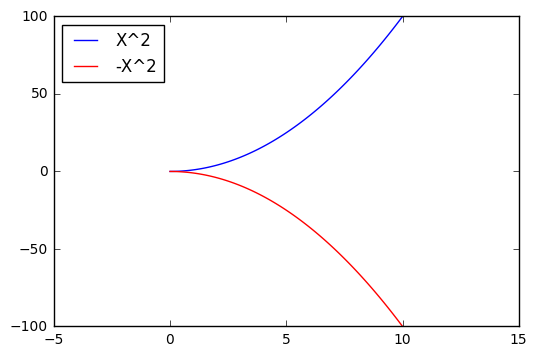

```python
fig, ax = plt.subplots()
ax.set_xlim(-5, 15)
ax.set_ylim(-100, 100)
legends = ax.plot(X,Y, 'b', X, [-y for y in Y], 'r')
print (legends)
plt.legend(legends, ["X^2", "-X^2"], loc=2) # loc=2 shmainei panw aristera
plt.show()
```

Περισσότερα για το loc (location του legend δείτε εδώ: http://matplotlib.org/api/legend_api.html#matplotlib.legend.Legend)

Επίσης μπορούμε να προσθέσουμε ενα grid:

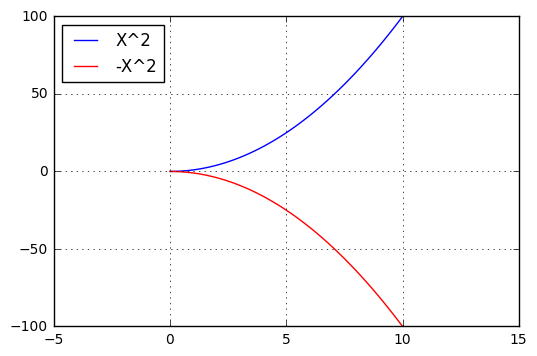

```python
fig, ax = plt.subplots()
ax.set_xlim(-5, 15)
ax.set_ylim(-100, 100)
legends = ax.plot(X,Y, 'b', X, [-y for y in Y], 'r')

ax.grid(True)

plt.legend(legends, ["X^2", "-X^2"], loc=2) # loc=2 shmainei panw aristera
plt.show()
```

Προσθέστε ένα κείμενο στο σημείο Χ,Υ :

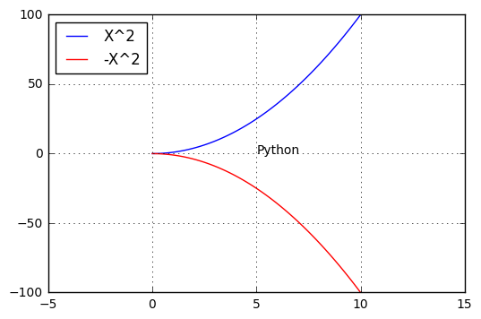

```python
fig, ax = plt.subplots()
ax.set_xlim(-5, 15)
ax.set_ylim(-100, 100)
legends = ax.plot(X,Y, 'b', X, [-y for y in Y], 'r')
ax.grid(True)

ax.text(5,0,"Python")

plt.legend(legends, ["X^2", "-X^2"], loc=2) # loc=2 shmainei panw aristera
plt.show()
```

Επίσης υπάρχει η [annotate](http://matplotlib.org/users/annotations_guide.html#plotting-guide-annotation) με την οποία μπορείτε να βάλετε βελάκια

Πολλές φορές θέλουμε να τυπώσουμε δύο plots τα οποία να μοιράζονται τον ίδιο άξονα. Ας υποθέσουμε π.χ. ότι θέλουμενα μοιράζονται το άξονα Χ :

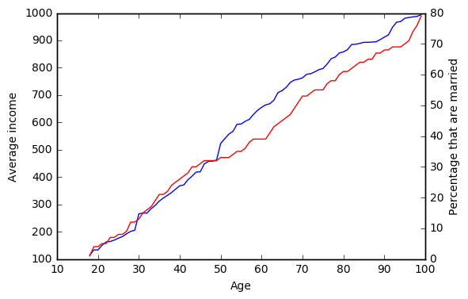

```python
fig, ax = plt.subplots()
import random

age = [x for x in range(18,100)]
income = sorted([random.randint(100,1000) for x in age])
percentage_married = sorted([random.randint(0, 80) for x in age])

legends_income = ax.plot(age, income, 'b')

# Dhmiourgoume ena antigrafo tou axona X
ax_new = ax.twinx()

# Plotaroume to deutero plot panw se auto
legends_married = ax_new.plot(age, percentage_married, 'r')

ax.set_xlabel("Age")
ax.set_ylabel("Average income")
ax_new.set_ylabel("Percentage that are married")

plt.show()
```

Επίσης μπορούμε να προσθέσουμε ένα ολόκληρο νέο πλότ μέσα σε ένα παλιό! Αυτό το κάνουμε με την εντολή [fig.add_axes()](http://matplotlib.org/api/figure_api.html#matplotlib.figure.Figure.add_axes). H add_axes **ΑΓΝΟΕΙ** το μέγεθος των αξόνων (π.χ. ο Χ έχει μέγεθος από 10 μέχρι 100 παραπάνω). Αντίθετα θεωρεί ότι ΟΛΟ το πλοτ είναι ένα καρτεσιανό γινόμενο [0,1]Χ[0,1] . Με την add_axes ορίζουμε τις διαστάσεις του νέου plot πάνω στο παλιό. Παράδειγμα

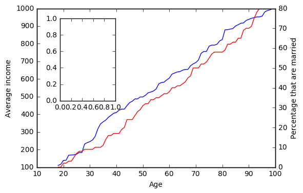

```python
fig, ax = plt.subplots()
import random

age = [x for x in range(18,100)]
income = sorted([random.randint(100,1000) for x in age])
percentage_married = sorted([random.randint(0, 80) for x in age])

legends_income = ax.plot(age, income, 'b')

# Dhmiourgoume ena antigrafo tou axona X
ax_new = ax.twinx()

# Plotaroume to deutero plot panw se auto
legends_married = ax_new.plot(age, percentage_married, 'r')

ax.set_xlabel("Age")
ax.set_ylabel("Average income")
ax_new.set_ylabel("Percentage that are married")


# Φτιάχνουμε νέο υπο-πλοτ:
ax_sub = fig.add_axes([0.2, 0.45, 0.18, 0.4])


plt.show()
```

Η σημασιολογία των παραμέτρων της `add_axes` φαίνεται στο παρακάτω σχήμα:

[figure not shown]

Ας πλοτάρουμε μέσα στο sub-plot:

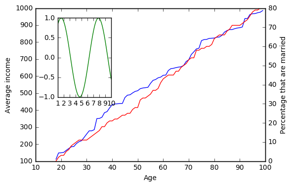

```python
fig, ax = plt.subplots()
import random

age = [x for x in range(18,100)]
income = sorted([random.randint(100,1000) for x in age])
percentage_married = sorted([random.randint(0, 80) for x in age])

legends_income = ax.plot(age, income, 'b')

# Dhmiourgoume ena antigrafo tou axona X
ax_new = ax.twinx()

# Plotaroume to deutero plot panw se auto
legends_married = ax_new.plot(age, percentage_married, 'r')

ax.set_xlabel("Age")
ax.set_ylabel("Average income")
ax_new.set_ylabel("Percentage that are married")


# Φτιάχνουμε νέο υπο-πλοτ:
ax_sub = fig.add_axes([0.2, 0.45, 0.18, 0.4])
sub_X = np.linspace(1,10,100)
sub_Y = np.sin(sub_X)
ax_sub.plot(sub_X,sub_Y, 'g')

plt.show()
```

Μπορούμε επίης να αλλάξουμε τη κλίμακα των αξόνων σε λογαριθμική:

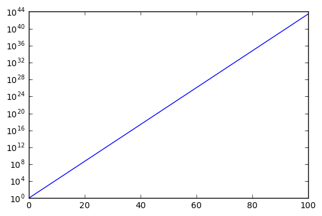

```python
fig, ax = plt.subplots()

X = np.linspace(0,100,1000)
Y = np.exp(X)

ax.plot(X,Y)

ax.set_yscale("log")
plt.show()
```

Μπορούμε να σώσουμε στο δίσκο ένα πλοτ μέσω της "plt.savefig()". Ανάλογα με την κατάληξη που θα βάλετε στο όνομα του αρχείου, θα το σώσει και σε διαφορετικό format. **ΠΡΟΣΟΧΗ!** τη savefig πρέπει να τη καλείτε ΠΡΙΝ τη plt.show()

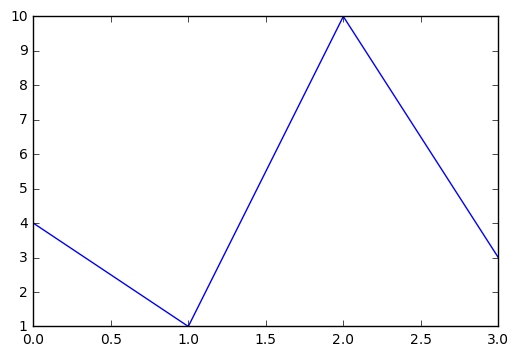

```python
fig, ax = plt.subplots()

ax.plot([4,1,10,3])

plt.savefig("figure.png")
plt.savefig("figure.jpg")
plt.savefig("figure.eps")
plt.savefig("figure.tiff")
plt.savefig("figure.pdf")

plt.show()
```

Και το παράδειγμα που δουλέψαμε στη διάλεξη:

```
[  0.   2.   4.   6.   8.  10.]
```

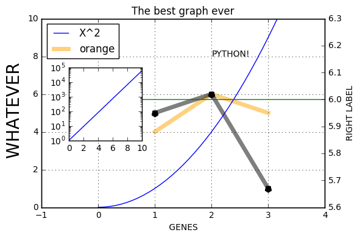

```python
def x2(x):
    return x*x

fig, ax = plt.subplots()
leg_orange, = ax.plot([1,2,3], [4,6,5,], '-', color="orange", lw="5", alpha=0.5)
ax.plot([1,2,3], [5,6,1,], '-', color="black", lw="5", alpha=0.5)
ax.plot([1,2,3], [5,6,1,], '*', color="black", lw="5", mew=5)
X = [x/10.0 for x in range(0,100)]
Y = [x2(x) for x in X]
leg_x2, = ax.plot(X, Y)

ticks = ax.get_xticks()
print (ticks)
#ticks = [str(x) + " a " for x in ticks]
# ax.set_xticklabels(ticks)
#ax.set_xticks([x for x in range(-1,5, 2)])
ax.set_xlabel(" GENES ")
ax.set_ylabel(" WHATEVER", fontsize=20)
ax.set_title("The best graph ever")
ax.grid(True)

ax_new = ax.twinx()
ax_new.plot([0,4], [6,6], color="green")
ax_new.set_ylabel("RIGHT LABEL")

ax.set_xlim(-1,4)
ax.set_ylim(0,10)

ax.text(2, 8, "PYTHON!")

plt.legend([leg_x2, leg_orange], ["X^2", "orange"], loc=2)
ax2 = fig.add_axes([0.2, 0.4, 0.2, 0.3])
X2 = [x/10.0 for x in range(0,100)]
Y2 = [3**x for x in X2]
ax2.set_yscale("log")

ax2.plot(X2, Y2)

plt.savefig("figure.png")
plt.savefig("figure.jpg")
plt.savefig("figure.eps")
plt.savefig("figure.tiff")
plt.show()
```

Κάποιες τελευταίες σημειώσεις:

- Η matplotlib είναι τεράστια! Ελέγξτε πόσο διαφορετικά plots μπορείτε να φτιάξετε: http://matplotlib.org/gallery.html .
- Υπάρχουν βιβλιοθήκες για plot-άρισμα συγκεκριμμένου τύπου δεδομένων οι οποίες βασίζονται στη matplotlib. Μία από τις καλύτερες (ΙΜΗΟ) είναι η [seaborn](http://seaborn.pydata.org/) η οποία προσανατολίζεται σε πλοτάρισμα κατανομών.
- H matplotlib έχει "κατηγορηθεί" ότι είναι καλή μεν αλλά δεν παράγει publication ready plots. Δηλαδή αισθητικά θέλουν λίγο δουλειά ακόμα πριν μπουν σε ένα paper. Διαβάστε σχετικά: https://github.com/jbmouret/matplotlib_for_papers , http://blog.dmcdougall.co.uk/publication-ready-the-first-time-beautiful-reproducible-plots-with-matplotlib/ , http://www.reddit.com/r/bioinformatics/comments/2cnv9g/polishing_your_python_matplotlib_plots_for/ , http://nipunbatra.github.io/2014/08/latexify/
- Η matplotlib ανοίκει στη κατηγορία των μη-interactive plots. Δλδ δεν μπορείς να αλληλεπιδράσεις με το plot (αν και στη τελευταία έκδοση έχουν προσθέσει κάποιες βασικές δυνατότητες). Φτιάχνει plots για παρουσιάσεις / papers και όχι για visual exploration! Στη 2η κατηγορία ανοίκουν άλλες βιβλιοθήκες όπως η [bokeh](http://bokeh.pydata.org/en/latest/) και η [plot.ly](https://plot.ly/). Αν υπάρξει λαϊκή απαίτηση μπορούμε να κάνουμε μία διάλεξη για αυτές!
- Το plot-άρισμα είναι τέχνη! Όσο καλή και αν είναι μία βιβλιοθήκη πρέπει κάποιος να γνωρίζει βασικά θέματα γραφιστικής / αισθητικής για να κάνει ένα καλό plot: http://journals.plos.org/ploscompbiol/article?id=10.1371/journal.pcbi.1003833